# Supplemental Figures and LASSO regression on trial-by-trial agreement vs participant and video features

Shari Liu

2022-08-10

# Overview

In this script, we produce a few supplemental plots, and we model the trial-by-trial accuracy of iCatcher (i.e. % agreement between iCatcher and a human rater), as predicted by an array of video and participant features, using lasso regression.

**Note**: The data required to reproduce this analysis is not open access, because it links individual participants’ looking behavior to demographic data.

## Features over all datasets

These are the per-trial or per-video features that are shared across all 3 datasets:

*Per-trial features:*

- Human-model agreement (% agreement, computed over frames; the thing we want to predict)
- Human-human agreement (same as above, but computed across two human raters)
- Model confidence (generated by iCatcher, averaged over frames within a trial)
- Average position of face (x, y)
- Standard deviation in location of face (i.e. face movement)
- Face density (i.e. # of pixels in face relative to size)

*Per-video features:*

- Child age in months (reported by parent, rounded to nearest month)
- Child gender (reported by parent)
- Child race and ethnicity (reported by parent) - reported differently across datasets
- Average luminance of video frames

## Features specific to Lookit

These are additional per-video features that are specific to the Lookit dataset:

- Skin tone (light, medium, dark)
- Eye color (light, dark)
- Did camera position or background move at all throughout experiment

```r
knitr::opts_chunk$set(echo = TRUE, message = FALSE, warning = FALSE)

## load required packages
ipak <- function (pkg) {
  new.pkg <- pkg[!(pkg %in% installed.packages()[, "Package"])]
  if (length(new.pkg))
    install.packages(new.pkg, dependencies = TRUE)
  sapply(pkg, require, character.only = TRUE)
}

packages <- c("reticulate", "lme4", "lmerTest", "effects", "lsmeans", "tidyverse", "cowplot", "glmnet", "patchwork", "data.table", "MuMIn", "ggExtra", "effectsize", "viridis", "selectiveInference")

ipak(packages)
```

```
## lattice theme set by effectsTheme()
## See ?effectsTheme for details.
```

```
## The 'lsmeans' package is now basically a front end for 'emmeans'.
## Users are encouraged to switch the rest of the way.
## See help('transition') for more information, including how to
## convert old 'lsmeans' objects and scripts to work with 'emmeans'.
```

```
## Note: As of version 1.0.0, cowplot does not change the
```

```
##   default ggplot2 theme anymore. To recover the previous
```

```
##   behavior, execute:
##   theme_set(theme_cowplot())
```

```
## This version of bslib is designed to work with shiny version 1.6.0 or higher.
```

```
##         reticulate               lme4           lmerTest            effects
##               TRUE               TRUE               TRUE               TRUE
##            lsmeans          tidyverse            cowplot             glmnet
##               TRUE               TRUE               TRUE               TRUE
##          patchwork         data.table              MuMIn            ggExtra
##               TRUE               TRUE               TRUE               TRUE
##         effectsize            viridis selectiveInference
##               TRUE               TRUE               TRUE
```

```r
# set summed contrasts
options(contrasts = c("contr.treatment", "contr.poly"))

#py_install("pandas")
source_python("pickle_reader.py")
pd <- import("pandas")

# fix bs with dplyr
detach("package:dplyr", unload = TRUE)
library("dplyr")
# function that converts lmm model summary to df
gen.m <- function(model) {
  df <- data.frame(coef(summary(model)))
  names(df) <- c("est", "se", "df", "t", "p")
  return(df)
}
```

# Read in data

```r
cal <- pd$read_pickle("metrics/metrics_cali-bw.p")
senegal <- pd$read_pickle("metrics/metrics_senegal.p")
lookit <- pd$read_pickle("metrics/metrics_lookit.p")

# set up empty dfs to be filled
cal.trial.df <- data.frame()
lookit.trial.df <- data.frame()
senegal.trial.df <- data.frame()

# produce trial-level dfs for each dataset

for (i in 1:length(cal)) {

  subj <- paste0("cal_", i)
  dataset <- "cal-bw"
  agemonths <- as.numeric(cal[i][[1]]$csv_info$child_age)
  race <- tolower(cal[i][[1]]$csv_info$child_race)
  gender <- tolower(cal[i][[1]]$csv_info$child_gender)
  luminance <- as.numeric(cal[i][[1]]$stats$luminance)

  # specific to cal-bw
  preterm <- as.logical(cal[i][[1]]$csv_info$child_preterm)

  # specific to lookit
  # camera_moved <- as.logical(lookit[i][[1]]$csv_info$camera_moved)
  # skin_tone <- tolower(lookit[i][[1]]$csv_info$child_skin_tone)
  # eye_color <- tolower(lookit[i][[1]]$csv_info$child_eye_color)
  camera_moved <- NA
  skin_tone <- NA
  eye_color <- NA

  n_trials <- length(cal[i][[1]]$human1_vs_machine_trials)
  for (j in 1:n_trials) {
      trial <- j
      hm_agreement <- cal[i][[1]]$human1_vs_machine_trials[[j]]$agreement
      hh_agreement <- cal[i][[1]]$human1_vs_human2_trials[[j]]$agreement
      confidence <- mean(cal[i][[1]]$human1_vs_machine_trials[[j]]$raw_confidence, na.rm=TRUE)
      face_density <- cal[i][[1]]$human1_vs_machine_trials[[j]]$avg_face_pixel_density
      face_x <- cal[i][[1]]$human1_vs_machine_trials[[j]]$avg_face_loc[1]
      face_y <- cal[i][[1]]$human1_vs_machine_trials[[j]]$avg_face_loc[2]
      face_movement <- cal[i][[1]]$human1_vs_machine_trials[[j]]$avg_face_loc_std
      cur_row <- data.frame(dataset, subj, agemonths, race, gender, luminance, preterm, camera_moved, skin_tone, eye_color, trial, hm_agreement, hh_agreement, confidence, face_density, face_x, face_y, face_movement)
      cal.trial.df <- rbind(cal.trial.df, cur_row)
  }
}

for (i in 1:length(lookit)) {

  subj <- paste0("lookit_", i)
  dataset <- "lookit"
  agemonths <- as.numeric(lookit[i][[1]]$csv_info$child_age)
  race <- tolower(lookit[i][[1]]$csv_info$child_race)
  gender <- tolower(lookit[i][[1]]$csv_info$child_gender)
  luminance <- as.numeric(lookit[i][[1]]$stats$luminance)
  # specific to cal-bw
  # preterm <- as.logical(cal[i][[1]]$csv_info$child_preterm)
  preterm <- NA

  # specific to lookit
  camera_moved <- lookit[i][[1]]$csv_info$camera_moved
  skin_tone <- tolower(lookit[i][[1]]$csv_info$child_skin_tone)
  eye_color <- tolower(lookit[i][[1]]$csv_info$child_eye_color)
  n_trials <- length(lookit[i][[1]]$human1_vs_machine_trials)

  for (j in 1:n_trials) {
      trial <- j
      hm_agreement <- lookit[i][[1]]$human1_vs_machine_trials[[j]]$agreement
      hh_agreement <- lookit[i][[1]]$human1_vs_human2_trials[[j]]$agreement
      face_density <- lookit[i][[1]]$human1_vs_machine_trials[[j]]$avg_face_pixel_density
      confidence <- mean(lookit[i][[1]]$human1_vs_machine_trials[[j]]$raw_confidence, na.rm=TRUE)
      face_x <- lookit[i][[1]]$human1_vs_machine_trials[[j]]$avg_face_loc[1]
      face_y <- lookit[i][[1]]$human1_vs_machine_trials[[j]]$avg_face_loc[2]
      face_movement <- lookit[i][[1]]$human1_vs_machine_trials[[j]]$avg_face_loc_std
      cur_row <- data.frame(dataset, subj, agemonths, race, gender, luminance, preterm, camera_moved, skin_tone, eye_color, trial, hm_agreement, hh_agreement, confidence, face_density, face_x, face_y, face_movement)
      lookit.trial.df <- rbind(lookit.trial.df, cur_row)
  }
}

for (i in 1:length(senegal)) {

  subj <- paste0("senegal_", i)
  dataset <- "senegal"
  n_trials <- length(senegal[i][[1]]$human1_vs_machine_trials)
  luminance <- as.numeric(senegal[i][[1]]$stats$luminance)

  agemonths <- as.numeric(senegal[i][[1]]$csv_info$child_age)
  race <- "black"
  gender <- tolower(senegal[i][[1]]$csv_info$child_gender)

  # specific to cal-bw
  # preterm <- as.logical(cal[i][[1]]$csv_info$child_preterm)
  preterm <- NA

  # specific to lookit
  # camera_moved <- as.logical(lookit[i][[1]]$csv_info$camera_moved)
  # skin_tone <- tolower(lookit[i][[1]]$csv_info$child_skin_tone)
  # eye_color <- tolower(lookit[i][[1]]$csv_info$child_eye_color)
  camera_moved <- NA
  skin_tone <- NA
  eye_color <- NA

  for (j in 1:n_trials) {
      trial <- j
      hm_agreement <- senegal[i][[1]]$human1_vs_machine_trials[[j]]$agreement
      hh_agreement <- senegal[i][[1]]$human1_vs_human2_trials[[j]]$agreement
      face_density <- senegal[i][[1]]$human1_vs_machine_trials[[j]]$avg_face_pixel_density
      confidence <- mean(senegal[i][[1]]$human1_vs_machine_trials[[j]]$raw_confidence, na.rm=TRUE)
      face_x <- senegal[i][[1]]$human1_vs_machine_trials[[j]]$avg_face_loc[1]
      face_y <- senegal[i][[1]]$human1_vs_machine_trials[[j]]$avg_face_loc[2]
      face_movement <- senegal[i][[1]]$human1_vs_machine_trials[[j]]$avg_face_loc_std
      cur_row <- data.frame(dataset, subj, agemonths, race, gender, preterm, luminance, camera_moved, skin_tone, eye_color, trial, hm_agreement, hh_agreement, confidence, face_density, face_x, face_y, face_movement)
      senegal.trial.df <- rbind(senegal.trial.df, cur_row)
  }
}

# bind them together and specify reference level for dataset
data.trial.df <- rbind(cal.trial.df, senegal.trial.df, lookit.trial.df)
data.trial.df$dataset <- factor(data.trial.df$dataset, levels = c("cal-bw", "senegal", "lookit"))
data.trial.df$race <- relevel(factor(data.trial.df$race), ref = "white")
data.trial.df$camera_moved <- relevel(factor(data.trial.df$camera_moved), ref = "no")
data.trial.df$face_x <- data.trial.df$face_x-0.5 # normalize so that 0 = center
data.trial.df$face_y <- data.trial.df$face_y-0.5 # normalize so that 0 = center

# make z-scored version of trial-level dataset, and z score within each dataset
data.trial.df.scaled <- data.trial.df %>%
  group_by(dataset) %>%
  mutate_at(vars("hm_agreement", "hh_agreement", "confidence", "luminance", "face_density", "face_x", "face_y", "face_movement", "agemonths"), scale)
```

```r
# summarize number of videos in each dataset
videos_per_dataset <- data.trial.df %>%
  group_by(dataset) %>%
  summarise(videos_per_dataset = length(unique(subj)))

# summarize number of observations present and missing
trials_per_video <- data.trial.df %>%
  group_by(dataset, subj) %>%
  summarise(total_trials_per_video = n())


trials_missing_per_video <- data.trial.df %>%
  group_by(dataset, subj) %>%
  filter(hm_agreement == "NaN" | hh_agreement == "NaN") %>%
  summarise(trials_missing_per_video = n())

trials_per_dataset <- trials_per_video %>%
  group_by(dataset) %>%
  summarise(trials_per_dataset = sum(total_trials_per_video))


trials_missing_per_dataset <- trials_missing_per_video %>%
  group_by(dataset) %>%
  summarise(trials_missing_per_dataset = sum(trials_missing_per_video))

summary <- full_join(full_join(full_join(videos_per_dataset, trials_per_video), trials_missing_per_dataset),trials_per_dataset)

summary_trials <- summary %>%
  select(dataset, trials_per_dataset, trials_missing_per_dataset) %>%
  unique() %>%
  mutate(trials_per_dataset_after_missing = trials_per_dataset - trials_missing_per_dataset)
```

Note: Missing values for Senegal are to be expected, because human-human agreement is only available for ~half of trials per video.

```r
knitr::kable(summary_trials)
```

| dataset | trials_per_dataset | trials_missing_per_dataset | trials_per_dataset_after_missing |
| --- | --- | --- | --- |
| cal-bw | 1924 | 63 | 1861 |
| senegal | 1146 | 570 | 576 |
| lookit | 1036 | 10 | 1026 |

```r
knitr::kable(summary)
```

| dataset | videos_per_dataset | subj | total_trials_per_video | trials_missing_per_dataset | trials_per_dataset |
| --- | --- | --- | --- | --- | --- |
| cal-bw | 65 | cal_1 | 30 | 63 | 1924 |
| cal-bw | 65 | cal_10 | 28 | 63 | 1924 |
| cal-bw | 65 | cal_11 | 30 | 63 | 1924 |
| cal-bw | 65 | cal_12 | 29 | 63 | 1924 |
| cal-bw | 65 | cal_13 | 31 | 63 | 1924 |
| cal-bw | 65 | cal_14 | 34 | 63 | 1924 |
| cal-bw | 65 | cal_15 | 28 | 63 | 1924 |
| cal-bw | 65 | cal_16 | 30 | 63 | 1924 |
| cal-bw | 65 | cal_17 | 38 | 63 | 1924 |
| cal-bw | 65 | cal_18 | 37 | 63 | 1924 |
| cal-bw | 65 | cal_19 | 29 | 63 | 1924 |
| cal-bw | 65 | cal_2 | 34 | 63 | 1924 |
| cal-bw | 65 | cal_20 | 20 | 63 | 1924 |
| cal-bw | 65 | cal_21 | 24 | 63 | 1924 |
| cal-bw | 65 | cal_22 | 36 | 63 | 1924 |
| cal-bw | 65 | cal_23 | 36 | 63 | 1924 |
| cal-bw | 65 | cal_24 | 31 | 63 | 1924 |
| cal-bw | 65 | cal_25 | 32 | 63 | 1924 |
| cal-bw | 65 | cal_26 | 27 | 63 | 1924 |
| cal-bw | 65 | cal_27 | 29 | 63 | 1924 |
| cal-bw | 65 | cal_28 | 31 | 63 | 1924 |
| cal-bw | 65 | cal_29 | 26 | 63 | 1924 |
| cal-bw | 65 | cal_3 | 38 | 63 | 1924 |
| cal-bw | 65 | cal_30 | 30 | 63 | 1924 |
| cal-bw | 65 | cal_31 | 28 | 63 | 1924 |
| cal-bw | 65 | cal_32 | 37 | 63 | 1924 |
| cal-bw | 65 | cal_33 | 28 | 63 | 1924 |
| cal-bw | 65 | cal_34 | 29 | 63 | 1924 |
| cal-bw | 65 | cal_35 | 31 | 63 | 1924 |
| cal-bw | 65 | cal_36 | 30 | 63 | 1924 |

[output cut: 125 more lines]

# Plots

```r
theme_set(theme_cowplot(12))
palette1 <- scale_fill_manual(values=c("#1590df", "#a675b4", "#57e345"))
palette2 <- scale_color_manual(values=c("#1590df", "#a675b4", "#57e345"))
```

## Features

```r
hm <- ggplot(data.trial.df, aes(dataset, hm_agreement, fill = dataset)) +
  geom_boxplot(outlier.alpha = 0) +
  geom_jitter(width = .05, height=0, alpha=.2) +
  stat_summary(geom = "errorbar", fun.data = "mean_se", colour = "white", width = .1) +
  stat_summary(geom = "point", fun.data = "mean_se", colour = "white") +
  ylab("% agreement, human vs model") +
  theme(legend.position = "none") +
  palette1 +
  palette2
```

```r
hh <- ggplot(data.trial.df, aes(dataset, hh_agreement, fill = dataset)) +
  geom_boxplot(outlier.alpha = 0) +
  geom_jitter(width = .1, height=0, alpha=.2) +
  stat_summary(geom = "errorbar", fun.data = "mean_se", colour = "white", width = .1) +
  stat_summary(geom = "point", fun.data = "mean_se", colour = "white") +
  ylab("% agreement, human vs human")+
  theme(legend.position = "none") +
  palette1 +
  palette2
```

```r
hm_hh <- ggplot(data.trial.df, aes(hh_agreement, hm_agreement, colour = dataset)) +
  # geom_boxplot(outlier.alpha = 0) +
  geom_point(width = .1, height=0, alpha=.5, aes(shape=dataset)) +
  geom_smooth() +
  ylab("% agreement, human vs model")+
  xlab("% agreement, human vs human")+
  theme(legend.position = "none") +
  palette1 +
  palette2
```

```r
hm_confidence <- ggplot(data.trial.df, aes(confidence, hm_agreement, colour = dataset)) +
  # geom_boxplot(outlier.alpha = 0) +
  geom_point(alpha=.3, aes(shape=dataset)) +
  geom_smooth() +
  ylab("% agreement, human vs model")+
  xlab("Model confidence")+
  theme(legend.position = "none") +
  palette1 +
  palette2 +
  theme_cowplot(16)
```

```r
fd <- ggplot(data.trial.df, aes(dataset, face_density, fill = dataset)) +
  geom_boxplot(outlier.alpha = 0) +
  geom_jitter(width = .1, height=0, alpha=.2) +
  stat_summary(geom = "errorbar", fun.data = "mean_se", colour = "white", width = .1) +
  stat_summary(geom = "point", fun.data = "mean_se", colour = "white") +
  ylab("Face density")+
  theme(legend.position = "none") +
  palette1 +
  palette2
```

```r
fx <- ggplot(data.trial.df, aes(dataset, face_x, fill = dataset)) +
  geom_boxplot(outlier.alpha = 0) +
  geom_jitter(width = .1, height=0, alpha=.2) +
  stat_summary(geom = "errorbar", fun.data = "mean_se", colour = "white", width = .1) +
  stat_summary(geom = "point", fun.data = "mean_se", colour = "white") +
  ylab("Face position relative to center (horizontal)") +
  coord_cartesian(ylim = c(-.4, .4)) +
  theme(legend.position = "none") +
  palette1 +
  palette2
```

```r
fx.accuracy <- ggplot(data.trial.df, aes(face_x, hm_agreement, colour = dataset)) +
  geom_point(width = .1, alpha=.2) +
  xlab("Face position relative to center (horizontal)") +
  geom_smooth() +
  theme(legend.position = "none") +
  palette1 +
  palette2
```

```r
fy.accuracy <- ggplot(data.trial.df, aes(face_y, hm_agreement, colour = dataset)) +
  geom_point(width = .1, alpha=.2) +
  xlab("Face position relative to center (vertical)") +
  geom_smooth() +
  theme(legend.position = "none") +
  palette1 +
  palette2
```

```r
fy <- ggplot(data.trial.df, aes(dataset, face_y , fill = dataset)) +
  geom_boxplot(outlier.alpha = 0) +
  geom_jitter(width = .1, height=0, alpha=.2) +
  stat_summary(geom = "errorbar", fun.data = "mean_se", colour = "white", width = .1) +
  stat_summary(geom = "point", fun.data = "mean_se", colour = "white") +
  ylab("Face position relative to center (vertical)") +
  coord_cartesian(ylim = c(-.4, .4)) +
  theme(legend.position = "none") +
  palette1 +
  palette2
```

```r
xy_summary <- data.trial.df %>%
  group_by(dataset) %>%
  summarise(face_x_mean = mean(face_x, na.rm=TRUE),
            face_y_mean = mean(face_y, na.rm=TRUE),
            face_x_se = sd(face_x, na.rm=TRUE)/sqrt(n()),
            face_y_se = sd(face_x, na.rm=TRUE)/sqrt(n()))

fxy <- ggplot(data.trial.df, aes(face_x, face_y, colour = dataset)) +
  stat_density_2d(aes(fill = ..level..), geom = "polygon", colour = "white", contour_var = "ndensity")  +
  # geom_hex(bins=30)+
  scale_fill_viridis(option="magma")+
  geom_point(data = xy_summary, aes(x = face_x_mean, y = face_y_mean),
                colour = "white", shape = "diamond", size = 5) +
  geom_rug(alpha = .1) +
  xlab("Face position relative to center (horizontal)") +
  ylab("Face position relative to center (vertical)") +
  coord_cartesian(ylim = c(-.4, .4), xlim = c(-.4, .4)) +
  facet_wrap(~dataset) +
  theme(legend.position = "none") +
  palette2
```

```r
fm <- ggplot(data.trial.df, aes(dataset, face_movement, fill = dataset)) +
  geom_boxplot(outlier.alpha = 0) +
  geom_jitter(width = .1, height=0, alpha=.2) +
  stat_summary(geom = "errorbar", fun.data = "mean_se", colour = "white", width = .1) +
  stat_summary(geom = "point", fun.data = "mean_se", colour = "white") +
  ylab("Face movement") +
  theme(legend.position = "none") +
  palette1 +
  palette2
```

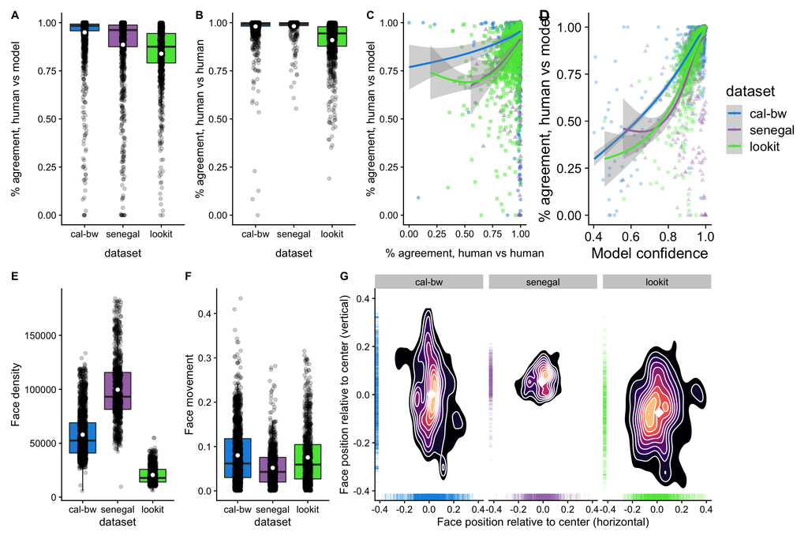

```r
row1 <- (hm | hh | hm_hh | hm_confidence)
row2 <- (fd | fm | fxy) + plot_layout(widths = c(1, 1, 3))

(row1 / row2) + plot_annotation(tag_levels = c('A', '1'))
```

## Breakdown of frames for training

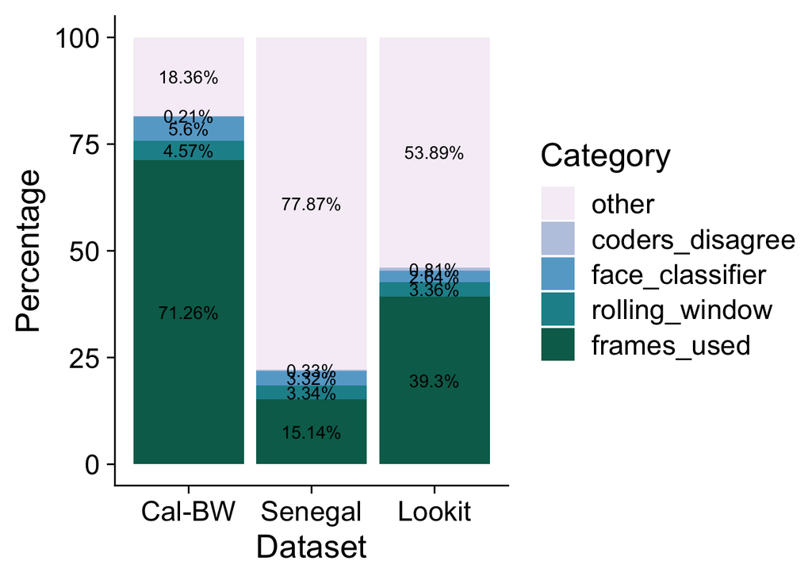

```r
training_info <- read.csv(file = "training_data_info.csv", header = TRUE) %>%
  select(-total) %>%
  pivot_longer(cols = c(frames_used:other), names_to = "Category", values_to = "Percentage")

training_info$Category <- factor(training_info$Category, levels = rev(c("frames_used", "rolling_window", "face_classifier", "coders_disagree", "other")))

training_info$dataset <- factor(training_info$dataset, levels = rev(c("cal-bw", "senegal", "lookit")))
levels(training_info$dataset) <- c("Cal-BW", "Senegal", "Lookit")

ggplot(training_info, aes(x = dataset, fill = Category, y = Percentage, label = paste0(Percentage, '%'))) +
  # geom_bar(position = "fill", stat = "identity") +
  geom_col() +
  xlab("Dataset") +
  geom_text(position = position_stack(vjust = 0.5)) +
  theme_cowplot(20) +
  scale_fill_brewer(palette = 10)
```

# Results per dataset

## (1) Cal-BW

```r
# use only complete observations
caldata <- data.trial.df %>%
  select(-camera_moved, -skin_tone, -eye_color) %>%
  drop_na()

caldata.z <- caldata %>%
  mutate_at(vars("hm_agreement", "hh_agreement", "confidence", "luminance", "face_density", "face_x", "face_y", "face_movement", "agemonths"), scale) %>%
  as.data.frame()

calpredictors <- sort(c('hh_agreement', 'confidence', 'face_density', 'face_x', 'face_y', 'face_movement', 'agemonths', 'gender', 'race', 'subj', 'luminance', 'preterm'))
caly <- caldata.z$hm_agreement
calx <- data.matrix(caldata.z[, calpredictors]) # only common predictors
dim(calx)
```

```
## [1] 1861   12
```

```r
length(caly)
```

```
## [1] 1861
```

```r
calsigma <- estimateSigma(calx, caly)$sigmahat
calfit <- lar(calx, caly, maxsteps=20)
caloutput <- larInf(calfit,
       sigma = calsigma,
       type = "aic",
       ntimes= 1,
       alpha = .05)

index <- caloutput$vars
names <- calpredictors[caloutput$vars]

cbind(index, names)
```

```
##      index names
## [1,] "2"   "confidence"
## [2,] "8"   "hh_agreement"
## [3,] "5"   "face_x"
## [4,] "10"  "preterm"
## [5,] "11"  "race"
```

```r
caloutput
```

```
##
## Call:
## larInf(obj = calfit, sigma = calsigma, alpha = 0.05, type = "aic",
##     ntimes = 1)
##
## Standard deviation of noise (specified or estimated) sigma = 0.610
##
## Testing results at step = 5, with alpha = 0.050
##
##  Var   Coef Z-score P-value LowConfPt UpConfPt LowTailArea UpTailArea
##    2  0.786  55.217   0.000     0.758    0.882       0.024      0.025
##    8  0.113   7.952   0.098    -0.069    0.137       0.025      0.024
##    5 -0.068  -4.749   0.849    -0.101      Inf       0.025      0.000
##   10 -0.113  -3.672   0.000      -Inf   -0.112       0.000      0.025
##   11  0.010   1.551   0.394    -0.165    0.235       0.025      0.025
##
## Estimated stopping point from AIC rule = 5
```

## (2) Senegal

```r
sendata <- data.trial.df %>%
  filter(dataset == "senegal") %>%
  select(-camera_moved, -skin_tone, -eye_color, -race, -preterm) %>% # only take vars that are present and that actually vary
  drop_na()

sendata.z <- sendata %>%
  mutate_at(vars("hm_agreement", "hh_agreement", "confidence", "luminance", "face_density", "face_x", "face_y", "face_movement", "agemonths"), scale)

senpredictors <- sort(c('hh_agreement', 'confidence', 'face_density', 'face_x', 'face_y', 'face_movement', 'agemonths', 'gender', 'subj', 'luminance'))
seny <- sendata.z$hm_agreement
senx <- data.matrix(sendata.z[, senpredictors]) # only common predictors
dim(senx)
```

```
## [1] 576  10
```

```r
length(seny)
```

```
## [1] 576
```

```r
sensigma <- estimateSigma(senx, seny)$sigmahat
senfit <- lar(senx, seny, maxsteps=20)
senoutput <- larInf(senfit,
       sigma = sensigma,
       type = "aic",
       ntimes= 1,
       alpha = .05)

index <- senoutput$vars
names <- senpredictors[senoutput$vars]

cbind(index, names)
```

```
##      index names
## [1,] "2"   "confidence"
## [2,] "6"   "face_y"
## [3,] "9"   "luminance"
## [4,] "8"   "hh_agreement"
## [5,] "5"   "face_x"
## [6,] "10"  "subj"
## [7,] "3"   "face_density"
## [8,] "7"   "gender"
```

```r
senoutput
```

```
##
## Call:
## larInf(obj = senfit, sigma = sensigma, alpha = 0.05, type = "aic",
##     ntimes = 1)
##
## Standard deviation of noise (specified or estimated) sigma = 0.783
##
## Testing results at step = 8, with alpha = 0.050
##
##  Var   Coef Z-score P-value LowConfPt UpConfPt LowTailArea UpTailArea
##    2  0.413  11.582   0.003     0.117    0.692       0.000      0.025
##    6  0.218   5.651   0.319    -0.516    0.471       0.025      0.025
##    9 -0.142  -4.191   0.352    -0.531    0.474       0.025      0.025
##    8  0.107   3.215   0.413    -0.441    0.378       0.025      0.025
##    5 -0.127  -3.771   0.700    -0.516    1.840       0.025      0.025
##   10  0.005   1.965   0.047    -0.005    0.254       0.025      0.025
##    3  0.154   4.060   0.023     0.007    1.361       0.025      0.025
##    7 -0.111  -1.529   0.715    -0.624    2.209       0.025      0.025
##
## Estimated stopping point from AIC rule = 8
```

## (3) Lookit

```r
# use only complete observations
lookitdata <- data.trial.df %>%
  filter(dataset == "lookit") %>%
  select(-preterm) %>% # only take vars that are present
  drop_na()
dim(lookitdata)
```

```
## [1] 1026   17
```

```r
lookitdata.z <- lookitdata %>%
  mutate_at(vars("hm_agreement", "hh_agreement", "confidence", "face_density", "face_x", "face_y", "face_movement", "agemonths", "luminance"), scale)

lookitpredictors <- sort(c('hh_agreement', 'confidence', 'face_density', 'face_x', 'face_y', 'face_movement', "camera_moved", "skin_tone", "eye_color", "agemonths", "race", "gender", "subj", "luminance"))

lookity <- lookitdata.z$hm_agreement
lookitx <- data.matrix(lookitdata.z[, lookitpredictors]) # assess race per dataset
dim(lookitx)
```

```
## [1] 1026   14
```

```r
length(lookity)
```

```
## [1] 1026
```

```r
lookitsigma <- estimateSigma(lookitx, lookity)$sigmahat
lookitfit <- lar(lookitx, lookity, maxsteps=20)
lookitoutput <- larInf(lookitfit,
       sigma = lookitsigma,
       type = "aic",
       ntimes= 1,
       alpha = .05)

index <- lookitoutput$vars
names <- lookitpredictors[lookitoutput$vars]

cbind(index, names)
```

```
##      index names
## [1,] "3"   "confidence"
## [2,] "10"  "hh_agreement"
## [3,] "6"   "face_movement"
## [4,] "13"  "skin_tone"
## [5,] "9"   "gender"
## [6,] "12"  "race"
## [7,] "5"   "face_density"
```

```r
lookitoutput
```

```
##
## Call:
## larInf(obj = lookitfit, sigma = lookitsigma, alpha = 0.05, type = "aic",
##     ntimes = 1)
##
## Standard deviation of noise (specified or estimated) sigma = 0.681
##
## Testing results at step = 7, with alpha = 0.050
##
##  Var   Coef Z-score P-value LowConfPt UpConfPt LowTailArea UpTailArea
##    3  0.613  26.679   0.000     0.422    0.672       0.000      0.025
##   10  0.208   9.187   0.000     0.139    0.698       0.025      0.025
##    6 -0.131  -5.129   0.077    -0.547    0.081       0.025      0.000
##   13  0.215   3.927   0.820    -4.402    0.421       0.025      0.025
##    9  0.132   2.430   0.083    -0.340    5.203       0.025      0.025
##   12  0.117   2.468   0.527    -1.160    0.813       0.025      0.025
##    5  0.125   4.660   0.200    -0.167    0.220       0.025      0.025
##
## Estimated stopping point from AIC rule = 7
```

# Results: All datasets together

```r
# use only complete observations
data <- data.trial.df %>%
  select(-camera_moved, -preterm, -skin_tone, -eye_color) %>% # only take vars that are present in all 3
  drop_na() %>%
  mutate(race = case_when(race == "white" ~ "white",
                          race == "white only" ~ "white",
                          TRUE ~ "non-white")) # because of differences in race coding, convert

data.z <- data %>%
  mutate_at(vars("hm_agreement", "hh_agreement", "confidence", "face_density", "face_x", "face_y", "face_movement", "agemonths", "luminance"), scale)

allpredictors <- sort(c('dataset', 'hh_agreement', 'confidence', 'face_density', 'face_x', 'face_y', 'face_movement', 'agemonths', 'gender', 'race', 'subj', 'luminance'))
y <- data.z$hm_agreement
x <- data.matrix(data.z[, allpredictors]) # only common predictors
dim(x)
```

```
## [1] 3463   12
```

```r
length(y)
```

```
## [1] 3463
```

```r
sigma <- estimateSigma(x, y)$sigmahat
fit <- lar(x, y, maxsteps=20)
output.all <- larInf(fit,
       sigma = estimateSigma(x, y)$sigmahat,
       type = "aic",
       ntimes = 1,
       alpha = .05)

index <- output.all$vars
names <- allpredictors[output.all$vars]

cbind(index, names)
```

```
##      index names
## [1,] "2"   "confidence"
## [2,] "9"   "hh_agreement"
## [3,] "3"   "dataset"
## [4,] "12"  "subj"
## [5,] "6"   "face_x"
## [6,] "7"   "face_y"
## [7,] "10"  "luminance"
## [8,] "1"   "agemonths"
```

```r
output.all
```

```
##
## Call:
## larInf(obj = fit, sigma = estimateSigma(x, y)$sigmahat, alpha = 0.05,
##     type = "aic", ntimes = 1)
##
## Standard deviation of noise (specified or estimated) sigma = 0.670
##
## Testing results at step = 8, with alpha = 0.050
##
##  Var   Coef Z-score P-value LowConfPt UpConfPt LowTailArea UpTailArea
##    2  0.647  54.025   0.000     0.547    0.828       0.000      0.025
##    9  0.169  13.472   0.000     0.136    0.194       0.025      0.025
##    3 -0.159  -5.389   0.377    -2.223    1.531       0.025      0.025
##   12  0.000  -0.917   0.528    -0.022    0.026       0.025      0.025
##    6 -0.058  -5.029   0.221    -0.120    0.088       0.025      0.025
##    7  0.030   2.483   0.478    -0.447    0.431       0.025      0.025
##   10 -0.036  -3.042   0.525    -0.619    0.759       0.025      0.025
##    1 -0.073  -3.794   0.385    -1.893    1.260       0.025      0.025
##
## Estimated stopping point from AIC rule = 8
```

### “Best” model explained variance

*WARNING*: The coefficients, p values, etc of these lme4 models should not be interpreted, because they do not take into account the fact that we did variable selection beforehand. The main value of interest is the conditional R^2 of the two models.

```r
options(contrasts = c("contr.treatment", "contr.poly"))

data.z <- data.trial.df %>%
  select(-camera_moved, -skin_tone, -eye_color, -preterm) %>%
  mutate_at(vars("hm_agreement", "hh_agreement", "confidence", "face_density", "face_x", "face_y", "face_movement", "agemonths", "luminance"), scale) %>%
  mutate(race = case_when(race == "white" ~ "white",
                          race == "white only" ~ "white",
                          TRUE ~ "non-white")) %>% # because of differences in race coding, convert
  drop_na()

data.z$race <- factor(data$race, levels = c("white", "non-white"))

model.all <- lmer(hm_agreement ~ confidence + hh_agreement + dataset + face_x + face_y + agemonths + luminance + (1|subj),
            data = data.z,
            REML = FALSE)

r.squaredGLMM(model.all)
```

```
##            R2m       R2c
## [1,] 0.5278137 0.6703336
```

```r
summary(model.all)
```

```
## Linear mixed model fit by maximum likelihood . t-tests use Satterthwaite's
##   method [lmerModLmerTest]
## Formula: hm_agreement ~ confidence + hh_agreement + dataset + face_x +
##     face_y + agemonths + luminance + (1 | subj)
##    Data: data.z
##
##      AIC      BIC   logLik deviance df.resid
##   6088.3   6155.9  -3033.1   6066.3     3452
##
## Scaled residuals:
##      Min       1Q   Median       3Q      Max
## -10.4576  -0.1688   0.0670   0.3457   7.4029
##
## Random effects:
##  Groups   Name        Variance Std.Dev.
##  subj     (Intercept) 0.1317   0.3629
##  Residual             0.3046   0.5519
## Number of obs: 3463, groups:  subj, 155
##
## Fixed effects:
##                  Estimate Std. Error         df t value Pr(>|t|)
## (Intercept)       0.15943    0.04894  125.42948   3.257  0.00145 **
## confidence        0.58160    0.01175 3456.53169  49.503  < 2e-16 ***
## hh_agreement      0.14888    0.01116 3396.95167  13.344  < 2e-16 ***
## datasetsenegal   -0.33946    0.08300  140.64410  -4.090 7.23e-05 ***
## datasetlookit    -0.22956    0.11715  134.29349  -1.960  0.05211 .
## face_x           -0.11375    0.01655 1864.11717  -6.873 8.54e-12 ***
## face_y            0.06259    0.01965 1400.93730   3.185  0.00148 **
## agemonths        -0.02900    0.05726  133.24391  -0.506  0.61341
## luminance        -0.07096    0.03174  135.86852  -2.236  0.02702 *
## ---
## Signif. codes:  0 '***' 0.001 '**' 0.01 '*' 0.05 '.' 0.1 ' ' 1
##
## Correlation of Fixed Effects:
##             (Intr) cnfdnc hh_grm dtstsn dtstlk face_x face_y agmnth
## confidence  -0.029
## hh_agreemnt -0.053 -0.111
## datasetsngl -0.452  0.015 -0.010
## datasetlokt -0.588  0.048  0.085 -0.080
## face_x      -0.010  0.066  0.007  0.034  0.004
## face_y      -0.027  0.069  0.005 -0.095  0.111  0.066
## agemonths   -0.251 -0.010  0.009 -0.389  0.761 -0.004  0.000
## luminance   -0.058 -0.001 -0.002  0.041  0.062  0.017 -0.068  0.148
```

```r
sjPlot::tab_model(model.all)
```

|  | hm agreement |  |  |
| --- | --- | --- | --- |
| Predictors | Estimates | CI | p |
| (Intercept) | 0.16 | 0.06 – 0.26 | **0.001** |
| confidence | 0.58 | 0.56 – 0.60 | **<0.001** |
| hh agreement | 0.15 | 0.13 – 0.17 | **<0.001** |
| dataset [senegal] | -0.34 | -0.50 – -0.18 | **<0.001** |
| dataset [lookit] | -0.23 | -0.46 – 0.00 | 0.050 |
| face x | -0.11 | -0.15 – -0.08 | **<0.001** |
| face y | 0.06 | 0.02 – 0.10 | **0.001** |
| agemonths | -0.03 | -0.14 – 0.08 | 0.613 |
| luminance | -0.07 | -0.13 – -0.01 | **0.025** |
| Random Effects |  |  |  |
| σ<sup>2</sup> | 0.30 |  |  |
| τ<sub>00</sub> <sub>subj</sub> | 0.13 |  |  |
| ICC | 0.30 |  |  |
| N <sub>subj</sub> | 155 |  |  |
| Observations | 3463 |  |  |
| Marginal R<sup>2</sup> / Conditional R<sup>2</sup> | 0.528 / 0.670 |  |  |

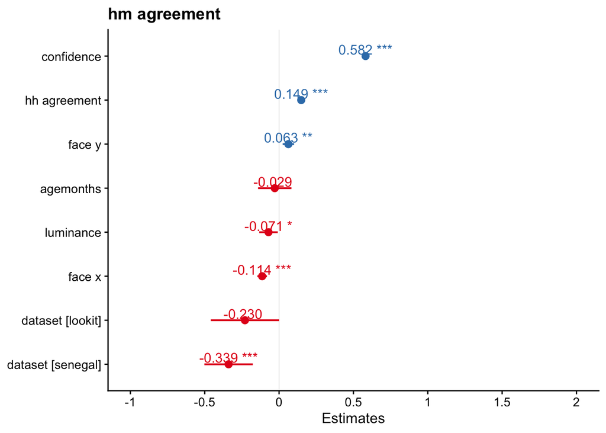

```r
sjPlot::plot_model(model.all, type = "est", show.values = TRUE, sort.est = TRUE, axis.lim = c(-1,2), show.p = TRUE, digits = 3)
```

```r
model.smaller <- lmer(hm_agreement ~ confidence + (1|subj),
            data = data.z,
            REML = FALSE)

r.squaredGLMM(model.smaller)
```

```
##            R2m       R2c
## [1,] 0.4448352 0.6288769
```

```r
summary(model.smaller)
```

```
## Linear mixed model fit by maximum likelihood . t-tests use Satterthwaite's
##   method [lmerModLmerTest]
## Formula: hm_agreement ~ confidence + (1 | subj)
##    Data: data.z
##
##      AIC      BIC   logLik deviance df.resid
##   6333.7   6358.3  -3162.8   6325.7     3459
##
## Scaled residuals:
##      Min       1Q   Median       3Q      Max
## -10.2758  -0.1185   0.0951   0.3361   7.4195
##
## Random effects:
##  Groups   Name        Variance Std.Dev.
##  subj     (Intercept) 0.1619   0.4024
##  Residual             0.3265   0.5714
## Number of obs: 3463, groups:  subj, 155
##
## Fixed effects:
##               Estimate Std. Error         df t value Pr(>|t|)
## (Intercept) -1.711e-04  3.407e-02  1.374e+02  -0.005    0.996
## confidence   6.057e-01  1.202e-02  3.455e+03  50.372   <2e-16 ***
## ---
## Signif. codes:  0 '***' 0.001 '**' 0.01 '*' 0.05 '.' 0.1 ' ' 1
##
## Correlation of Fixed Effects:
##            (Intr)
## confidence 0.018
```

```r
sjPlot::tab_model(model.smaller)
```

|  | hm agreement |  |  |
| --- | --- | --- | --- |
| Predictors | Estimates | CI | p |
| (Intercept) | -0.00 | -0.07 – 0.07 | 0.996 |
| confidence | 0.61 | 0.58 – 0.63 | **<0.001** |
| Random Effects |  |  |  |
| σ<sup>2</sup> | 0.33 |  |  |
| τ<sub>00</sub> <sub>subj</sub> | 0.16 |  |  |
| ICC | 0.33 |  |  |
| N <sub>subj</sub> | 155 |  |  |
| Observations | 3463 |  |  |
| Marginal R<sup>2</sup> / Conditional R<sup>2</sup> | 0.445 / 0.629 |  |  |

```r
anova(model.smaller, model.all)
```

```
## Data: data.z
## Models:
## model.smaller: hm_agreement ~ confidence + (1 | subj)
## model.all: hm_agreement ~ confidence + hh_agreement + dataset + face_x +
## model.all:     face_y + agemonths + luminance + (1 | subj)
##               npar    AIC    BIC  logLik deviance  Chisq Df Pr(>Chisq)
## model.smaller    4 6333.7 6358.3 -3162.8   6325.7
## model.all       11 6088.3 6155.9 -3033.1   6066.3 259.39  7  < 2.2e-16 ***
## ---
## Signif. codes:  0 '***' 0.001 '**' 0.01 '*' 0.05 '.' 0.1 ' ' 1
```